# Alex Dien

> Project Final Submission

> Alex Dien

> Table of Contents

> Task 1 - Libraries and Importing the dataset

> > > What are libraries and why do we need them?

> > > Import data

> > > What is a dataframe?

> Task 2 - High-level exploration of the dataset

> > Show the length of data set

> > > Write a brief interpretation of each column evaluated. Are there any patterns worth noting?

> Task 3 - Column by column exploration

> > Excluding the target variable: For each column in the dataset use your analysis skills to explore the column using descriptive summaries and graphs. For each column after reading the exploration I should know what the data type is, what values are in the column, for categorical you should describe the counts, for continuous mean, median, standard deviation among possible others (that list is NOT comprehensive of what I would expect).

> > > Age column (continuous)

> > > Workclass column (categorical)

> > > Fnlwgt column (continuous)

> > > Education column (categorical)

> > > Education-num column (continuous)

> > > Marital-status column (categorical)

> > > Occupation column (categorical)

> > > Relationship column (categorical)

> > > Race column (categorical)

> > > Sex column (categorical)

> > > Capital-gain column (continuous)

> > > Capital-loss column (continuous)

> > > Hrs-per-week column (continuous)

> > > Native-country column (categorical)

> > > *1) Is the data mining task a classification or regression task? In a text block explain the difference between the two.*

> > > 2) Is the target variable balanced or imbalanced? Why is this important?

> > > 3) What a majority classifier's accuracy would be on this target variable. ie what accuracy do we need to beat to do better than a majority classifier?

> > > *4) What classification performance metrics will you be using based on what you have learned about the target variable. Rank the metrics you will be using from most important to least important and explain your reasoning for the ranking.*

> Task 4 - Target Variable Exploration

> > > Write your interpretation of any predictors that appear to have an obvious relationship with the target.

> Task 5 - Target exploration by Predictors

> > > Do any particular models stand out as exceptional?

> > > What metrics are you using for your analysis and comparison? I am using Accuracy, Precison, Recall, and F1 score to analyze and compare.

> > > Describe the strengths and weaknesses of each metric.

> Task 6 - Data Encoding

> > > Pop the target variable. If necessary encode the target variable.

> > > In a text block make a column by column explanation for one-hot encoding your predictor dataframe.

> > > Columns

> > Workclass: We one-hot encode the 'workclass' predictor column because it contains categorical data. After one-hot encoding the 'workclass' column, each of its unique values will be represented by a new binary column, with a value of 1 indicating that the sample belongs to that category. The resulting data will be in a numeric form that can be used for analysis such as the bar charts above. This splits up the column to several categories such as 'Federal-gov' and 'Local-gov', which each contain its own numerical data.

> > Education: We one-hot encode the 'education' predictor column because it contains categorical data. After one-hot encoding the 'education' column, each of its unique values will be represented by a new binary column, with a value of 1 indicating that the sample belongs to that category. The resulting data will be in a numeric form that can be used for analysis. This splits up the column into categories such as 'Bachelors' and 'Masters', which each contain its own numerical data.

> > Marital-Status: We one-hot encode the 'marital-status' predictor column because it contains categorical data. After one-hot encoding the 'marital-status' column, each of its unique values will be represented by a new binary column, with a value of 1 indicating that the sample belongs to that category. The resulting data will be in a numeric form that can be used for analysis. This splits up the column into categories such as 'Married-civ-spouse' and 'Never-married', which each contain their own numerical data.

> > Occupation: The 'occupation' column is also a categorical predictor column that contains text data. After one-hot encoding this column, each of its unique values will be represented by a new binary column, with a value of 1 indicating that the sample belongs to that category. The resulting data will be in a numeric form that can be used for analysis such as bar charts. This splits the column into categories such as 'Tech-support' and 'Sales', which each contain their own numerical data.

> > Relationship: The 'relationship' column is also a categorical predictor column that contains text data. After one-hot encoding this column, each of its unique values will be represented by a new binary column, with a value of 1 indicating that the sample belongs to that category. The resulting data will be in a numeric form that can be used for analysis such as bar charts. This splits the column into categories such as 'Husband' and 'Not-in-family', which each contain their own numerical data.

> > Race: The 'race' column is also a categorical predictor column that contains text data. After one-hot encoding this column, each of its unique values will be represented by a new binary column, with a value of 1 indicating that the sample belongs to that category. The resulting data will be in a numeric form that can be used for analysis such as bar charts. This splits the column into categories such as 'White' and 'Black', which each contain their own numerical data.

> > Sex: The 'sex' column is also a categorical predictor column that contains text data. After one-hot encoding this column, each of its unique values will be represented by a new binary column, with a value of 1 indicating that the sample belongs to that category. The resulting data will be in a numeric form that can be used for analysis such as bar charts. This splits the column into the categories 'Male' and 'Female', which each contain their own numerical data.

> > Native-Country: The 'native-country' column is also a categorical predictor column that contains text data. After one-hot encoding this column, each of its unique values will be represented by a new binary column, with a value of 1 indicating that the sample belongs to that category. The resulting data will be in a numeric form that can be used for analysis such as bar charts. This splits the column into categories such as 'United-States' and 'Mexico', which each contain their own numerical data.

> Comparison to baseline

> Task 7 - Model Building

> > > Decision Tree

> > > SVM

> > > MLP

> > > KNN

> > > Majority-Classifier

> Final Model Recommendation

> Mount and Export

# Task 1 - Libraries and Importing the dataset

```python
# install libraries
import numpy as np # The numpy library is used for working with arrays. It contains important functions when working with math-related tasks. Since arrays are frequently used in data science, we use this library for its speed and resources.
import pandas as pd # This package is widely used for data science/analysis and ML tasks. It is built on top of Numpy.
import matplotlib.pyplot as plt # This library gives us tools to visualize our data using plots.

import seaborn as sns # Imported to get the libraries for pairplot.

from sklearn.model_selection import RandomizedSearchCV # Searches for a random subet of the possible combinations of hyperparams
from sklearn.model_selection import GridSearchCV # Searches for the full space of hyperparams
from sklearn import metrics # Import for metrics library
from sklearn.model_selection import cross_validate # Import this to use it in the scoring metrics

# These imports are necessary because the metrics (accuracy_score, precision_score, recall_score,
#and f1_score) are not included in the sklearn library by default. The make_scorer function allows
# us to create a custom scoring function that can be used to evaluate the performance of a model.
from sklearn.metrics import make_scorer, accuracy_score, precision_score, recall_score, f1_score

# Define the scoring functions, we use macro to combine the results and calculate the overall scores
accuracy_scorer = make_scorer(accuracy_score)
precision_scorer = make_scorer(precision_score, average='macro')
recall_scorer = make_scorer(recall_score, average='macro')
f1_scorer = make_scorer(f1_score, average='macro')


# Decision Tree
from sklearn.tree import DecisionTreeClassifier # Import for the Decision Tree model
from sklearn import tree # Import for tree plot visual

# SVM
from sklearn.svm import SVC # Import this to use the SVM library

# MLP
from sklearn.neural_network import MLPClassifier # Import this to use ths MLPClassifier

# KNN
from sklearn.neighbors import KNeighborsClassifier # Import this to use the KNeighborsClassifier

# Majority Classifier
from sklearn.ensemble import VotingClassifier # Ensemble method that combines the predictions from multiple models and makes final prediction based on majority vote
```

### What are libraries and why do we need them?

Python libraries help us create models and applications for our specific use cases, such as machine learning, data science, data visualization, etc. They provide a set of useful functions and eliminate the need to write functions from scratch. This saves developers lots of time so they can focus on more important things.

### Import data

```python
df = pd.read_csv("https://raw.githubusercontent.com/matthewpecsok/4482_fall_2022/main/data/census.csv")
```

```python
df_orig = df.copy() # I create a copy of this dataframe so I can refer to it later on as I will manipulate the other df
```

### What is a dataframe?

A dataframe is essentially like a spreadsheet or SQL table. It is a 2D data structure with columns of potentially different data types. It organizes data into a table of rows and columns.

# Task 2 - High-level exploration of the dataset

## 1. Show the length of data set

```python
df.info()
```

```
<class 'pandas.core.frame.DataFrame'>
RangeIndex: 32561 entries, 0 to 32560
Data columns (total 15 columns):
 #   Column          Non-Null Count  Dtype
---  ------          --------------  -----
 0   age             32561 non-null  int64
 1   workclass       32561 non-null  object
 2   fnlwgt          32561 non-null  int64
 3   education       32561 non-null  object
 4   education-num   32561 non-null  int64
 5   marital-status  32561 non-null  object
 6   occupation      32561 non-null  object
 7   relationship    32561 non-null  object
 8   race            32561 non-null  object
 9   sex             32561 non-null  object
 10  capital-gain    32561 non-null  int64
 11  capital-loss    32561 non-null  int64
 12  hours-per-week  32561 non-null  int64
 13  native-country  32561 non-null  object
 14  y               32561 non-null  object
dtypes: int64(6), object(9)
memory usage: 3.7+ MB
```

### Write a brief interpretation of each column evaluated. Are there any patterns worth noting?

**age:** This column contains the age of the individual in years. The values are continuous, which means they can take on any value within a given range.

**workclass:** This categorical column indicates the type of employment of the individual. The possible values are Private, Self-emp-not-inc, Self-emp-inc, Federal-gov, Local-gov, State-gov, Without-pay, and Never-worked.

**fnlwgt:** This column represents the final weight of the individual, which is a statistic that is used to represent the relative importance of a sample. The values are continuous.

**education:** This categorical column indicates the highest level of education that the individual has attained. The possible values are Bachelors, Some-college, 11th, HS-grad, Prof-school, Assoc-acdm, Assoc-voc, 9th, 7th-8th, 12th, Masters, 1st-4th, 10th, Doctorate, 5th-6th, and Preschool.

**education-num:** This column represents the number of years of education that the individual has completed. The values are continuous.

**marital-status:** This categorical column indicates the marital status of the individual. The possible values are Married-civ-spouse, Divorced, Never-married, Separated, Widowed, Married-spouse-absent, and Married-AF-spouse.

**occupation:** This categorical column indicates the occupation of the individual. The possible values are Tech-support, Craft-repair, Other-service, Sales, Exec-managerial, Prof-specialty, Handlers-cleaners, Machine-op-inspct, Adm-clerical, Farming-fishing, Transport-moving, Priv-house-serv, Protective-serv, and Armed-Forces.

**relationship:** This categorical column indicates the relationship of the individual to their household. The possible values are Wife, Own-child, Husband, Not-in-family, Other-relative, and Unmarried. race: This column indicates the race of the individual. The possible values are White, Asian-Pac-Islander, Amer-Indian-Eskimo, Other, and Black.

**sex:** This categorical column indicates the gender of the individual. The possible values are Female and Male.

**capital-gain:** This column indicates the capital gains of the individual. The values are continuous.

**capital-loss:** This column indicates the capital losses of the individual. The values are continuous.

**hours-per-week:** This column indicates the number of hours per week that the individual works. The values are continuous.

**native-country:** This categorical column indicates the country of origin of the individual. The possible values are United-States, Cambodia, England, Puerto-Rico, Canada, Germany, Outlying-US(Guam-USVI-etc), India, Japan, Greece, South, China, Cuba, Iran, Honduras, Philippines, Italy, Poland, Jamaica, Vietnam, Mexico, Portugal, Ireland, France, Dominican-Republic, Laos, Ecuador, Taiwan, Haiti, Columbia, Hungary, Guatemala, Nicaragua, Scotland, Thailand, Yugoslavia, El-Salvador, Trinadad&Tobago, Peru, Hong, and Holand-Netherlands.

**Some patterns in the data:**

- Most of the column types are objects, which means they contain strings.
- Some of the column names contain hyphens, which is not valid in Python which will cause errors when trying to reference them.

```python
# Show overall structure
df.describe()
```

|  | age | fnlwgt | education-num | capital-gain | capital-loss | hours-per-week |
| --- | --- | --- | --- | --- | --- | --- |
| count | 32561.000000 | 3.256100e+04 | 32561.000000 | 32561.000000 | 32561.000000 | 32561.000000 |
| mean | 38.581647 | 1.897784e+05 | 10.080679 | 1077.648844 | 87.303830 | 40.437456 |
| std | 13.640433 | 1.055500e+05 | 2.572720 | 7385.292085 | 402.960219 | 12.347429 |
| min | 17.000000 | 1.228500e+04 | 1.000000 | 0.000000 | 0.000000 | 1.000000 |
| 25% | 28.000000 | 1.178270e+05 | 9.000000 | 0.000000 | 0.000000 | 40.000000 |
| 50% | 37.000000 | 1.783560e+05 | 10.000000 | 0.000000 | 0.000000 | 40.000000 |
| 75% | 48.000000 | 2.370510e+05 | 12.000000 | 0.000000 | 0.000000 | 45.000000 |
| max | 90.000000 | 1.484705e+06 | 16.000000 | 99999.000000 | 4356.000000 | 99.000000 |

```python
# Summary of df
df.head()
```

|  | age | workclass | fnlwgt | education | education-num | marital-status | occupation | relationship | race | sex | capital-gain | capital-loss | hours-per-week | native-country | y |
| --- | --- | --- | --- | --- | --- | --- | --- | --- | --- | --- | --- | --- | --- | --- | --- |
| 0 | 39 | State-gov | 77516 | Bachelors | 13 | Never-married | Adm-clerical | Not-in-family | White | Male | 2174 | 0 | 40 | United-States | <=50K |
| 1 | 50 | Self-emp-not-inc | 83311 | Bachelors | 13 | Married-civ-spouse | Exec-managerial | Husband | White | Male | 0 | 0 | 13 | United-States | <=50K |
| 2 | 38 | Private | 215646 | HS-grad | 9 | Divorced | Handlers-cleaners | Not-in-family | White | Male | 0 | 0 | 40 | United-States | <=50K |
| 3 | 53 | Private | 234721 | 11th | 7 | Married-civ-spouse | Handlers-cleaners | Husband | Black | Male | 0 | 0 | 40 | United-States | <=50K |
| 4 | 28 | Private | 338409 | Bachelors | 13 | Married-civ-spouse | Prof-specialty | Wife | Black | Female | 0 | 0 | 40 | Cuba | <=50K |

```python
# Last 5 rows of df
df.tail()
```

|  | age | workclass | fnlwgt | education | education-num | marital-status | occupation | relationship | race | sex | capital-gain | capital-loss | hours-per-week | native-country | y |
| --- | --- | --- | --- | --- | --- | --- | --- | --- | --- | --- | --- | --- | --- | --- | --- |
| 32556 | 27 | Private | 257302 | Assoc-acdm | 12 | Married-civ-spouse | Tech-support | Wife | White | Female | 0 | 0 | 38 | United-States | <=50K |
| 32557 | 40 | Private | 154374 | HS-grad | 9 | Married-civ-spouse | Machine-op-inspct | Husband | White | Male | 0 | 0 | 40 | United-States | >50K |
| 32558 | 58 | Private | 151910 | HS-grad | 9 | Widowed | Adm-clerical | Unmarried | White | Female | 0 | 0 | 40 | United-States | <=50K |
| 32559 | 22 | Private | 201490 | HS-grad | 9 | Never-married | Adm-clerical | Own-child | White | Male | 0 | 0 | 20 | United-States | <=50K |
| 32560 | 52 | Self-emp-inc | 287927 | HS-grad | 9 | Married-civ-spouse | Exec-managerial | Wife | White | Female | 15024 | 0 | 40 | United-States | >50K |

```python
# Number of rows and columns
df.shape
```

```
(32561, 15)
```

```python
# Shows the amount of nulls for each column
df.isnull().sum()
```

```
age               0
workclass         0
fnlwgt            0
education         0
education-num     0
marital-status    0
occupation        0
relationship      0
race              0
sex               0
capital-gain      0
capital-loss      0
hours-per-week    0
native-country    0
y                 0
dtype: int64
```

# Task 3 - Column by column exploration

## 1. Excluding the target variable: For each column in the dataset use your analysis skills to explore the column using descriptive summaries and graphs. For each column after reading the exploration I should know what the data type is, what values are in the column, for categorical you should describe the counts, for continuous mean, median, standard deviation among possible others (that list is NOT comprehensive of what I would expect).

```python
df.info()
ednum = df['education-num']
marstat = df['marital-status']
# Had to do this to these two columns since they both contained hyphens, which made them unreadable when trying to read value counts.
```

```
<class 'pandas.core.frame.DataFrame'>
RangeIndex: 32561 entries, 0 to 32560
Data columns (total 15 columns):
 #   Column          Non-Null Count  Dtype
---  ------          --------------  -----
 0   age             32561 non-null  int64
 1   workclass       32561 non-null  object
 2   fnlwgt          32561 non-null  int64
 3   education       32561 non-null  object
 4   education-num   32561 non-null  int64
 5   marital-status  32561 non-null  object
 6   occupation      32561 non-null  object
 7   relationship    32561 non-null  object
 8   race            32561 non-null  object
 9   sex             32561 non-null  object
 10  capital-gain    32561 non-null  int64
 11  capital-loss    32561 non-null  int64
 12  hours-per-week  32561 non-null  int64
 13  native-country  32561 non-null  object
 14  y               32561 non-null  object
dtypes: int64(6), object(9)
memory usage: 3.7+ MB
```

### Age column (continuous)

```python
# Since it is continuous, it's better to use summary statistics and visualizations.
age = df.age
age.describe()
```

```
count    32561.000000
mean        38.581647
std         13.640433
min         17.000000
25%         28.000000
50%         37.000000
75%         48.000000
max         90.000000
Name: age, dtype: float64
```

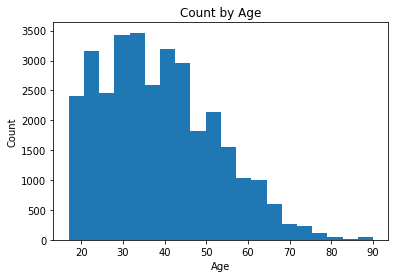

```python
# Visualize using histogram
# Create a histogram
plt.hist(age, bins=20) # Use bins of 20 to show a more detailed picture of the distribution.
plt.xlabel('Age')
plt.ylabel('Count')
plt.title('Count by Age')
plt.show()
```

### Workclass column (categorical)

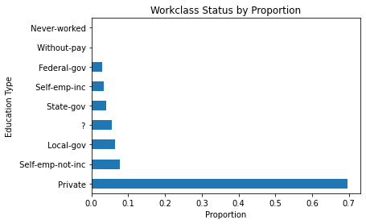

```python
# Analyze the workclass category by using plots
df.workclass.value_counts(normalize=True).plot.barh()

# Label the plot
plt.xlabel('Proportion')
plt.ylabel('Education Type')
plt.title('Workclass Status by Proportion')
plt.show()
```

### Fnlwgt column (continuous)

```python
# Compute summary statistics for continuous variables
fnlwgt = df.fnlwgt
fnlwgt.describe()
```

```
count    3.256100e+04
mean     1.897784e+05
std      1.055500e+05
min      1.228500e+04
25%      1.178270e+05
50%      1.783560e+05
75%      2.370510e+05
max      1.484705e+06
Name: fnlwgt, dtype: float64
```

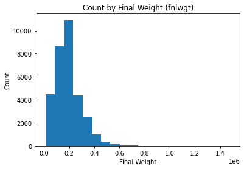

```python
# Visualize using histogram
# Create a histogram
plt.hist(fnlwgt, bins=20)
plt.xlabel('Final Weight')
plt.ylabel('Count')
plt.title('Count by Final Weight (fnlwgt)')
plt.show()
```

### Education column (categorical)

```python
df.education.value_counts(normalize=True)
```

```
 HS-grad         0.322502
 Some-college    0.223918
 Bachelors       0.164461
 Masters         0.052916
 Assoc-voc       0.042443
 11th            0.036086
 Assoc-acdm      0.032769
 10th            0.028654
 7th-8th         0.019840
 Prof-school     0.017690
 9th             0.015786
 12th            0.013298
 Doctorate       0.012684
 5th-6th         0.010227
 1st-4th         0.005160
 Preschool       0.001566
Name: education, dtype: float64
```

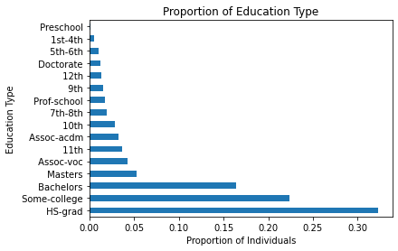

```python
# Analyze the education category by using plots
df.education.value_counts(normalize=True).plot.barh()

# Label the plot
plt.xlabel('Proportion of Individuals')
plt.ylabel('Education Type')
plt.title('Proportion of Education Type')
plt.show()
```

### Education-num column (continuous)

```python
# Compute summary statistics for continuous variables
ednum.describe()
```

```
count    32561.000000
mean        10.080679
std          2.572720
min          1.000000
25%          9.000000
50%         10.000000
75%         12.000000
max         16.000000
Name: education-num, dtype: float64
```

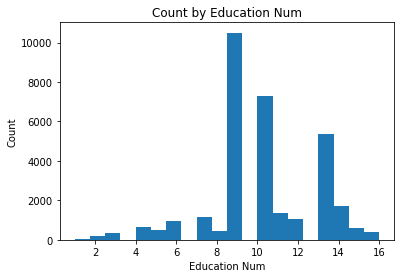

```python
# Visualize using histogram
# Create a histogram
plt.hist(ednum, bins=20)
plt.xlabel('Education Num')
plt.ylabel('Count')
plt.title('Count by Education Num')
plt.show()
```

### Marital-status column (categorical)

```python
marstat.value_counts(normalize=True)
```

```
 Married-civ-spouse       0.459937
 Never-married            0.328092
 Divorced                 0.136452
 Separated                0.031479
 Widowed                  0.030497
 Married-spouse-absent    0.012837
 Married-AF-spouse        0.000706
Name: marital-status, dtype: float64
```

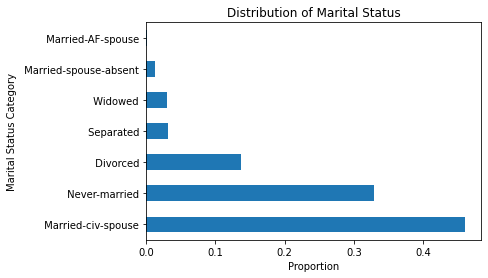

```python
# Analyze the marital-status category by using plots
marstat.value_counts(normalize=True).plot.barh()
plt.xlabel('Proportion')
plt.ylabel('Marital Status Category')
plt.title('Distribution of Marital Status')
plt.show()
```

### Occupation column (categorical)

```python
df.occupation.value_counts(normalize=True)
```

```
 Prof-specialty       0.127146
 Craft-repair         0.125887
 Exec-managerial      0.124873
 Adm-clerical         0.115783
 Sales                0.112097
 Other-service        0.101195
 Machine-op-inspct    0.061485
 ?                    0.056601
 Transport-moving     0.049046
 Handlers-cleaners    0.042075
 Farming-fishing      0.030527
 Tech-support         0.028500
 Protective-serv      0.019932
 Priv-house-serv      0.004576
 Armed-Forces         0.000276
Name: occupation, dtype: float64
```

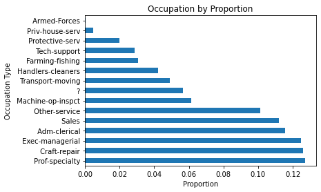

```python
# Analyze the marital-status category by using plots
df.occupation.value_counts(normalize=True).plot.barh()

# Label the plot
plt.xlabel('Proportion')
plt.ylabel('Occupation Type')
plt.title('Occupation by Proportion')
plt.show()
```

### Relationship column (categorical)

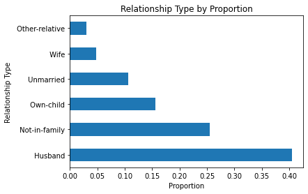

```python
df.relationship.value_counts(normalize=True).plot.barh()

# Label the plot
plt.xlabel('Proportion')
plt.ylabel('Relationship Type')
plt.title('Relationship Type by Proportion')
plt.show()
```

### Race column (categorical)

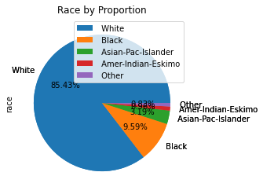

```python
# Analyze the race category by using a pie chart this time to switch it up.
df.race.value_counts(normalize=True).plot.pie()

# Label the plot with a legend
plt.title('Race by Proportion')
plt.legend(labels=df.race.value_counts(normalize=True).index,
           loc="upper right")
# Add percentages to the pie chart
df.race.value_counts(normalize=True).plot.pie(autopct="%.2f%%")

plt.show()
```

### Sex column (categorical)

```python
df.sex.value_counts(normalize=True)
```

```
 Male      0.669205
 Female    0.330795
Name: sex, dtype: float64
```

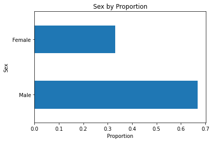

```python
# Analyze the sex category by using plots, using diff colors
df.sex.value_counts(normalize=True).plot.barh()

# Label the plot
plt.xlabel('Proportion')
plt.ylabel('Sex')
plt.title('Sex by Proportion')
plt.show()
```

### Capital-gain column (continuous)

```python
capgain = df['capital-gain']
capgain.describe()
```

```
count    32561.000000
mean      1077.648844
std       7385.292085
min          0.000000
25%          0.000000
50%          0.000000
75%          0.000000
max      99999.000000
Name: capital-gain, dtype: float64
```

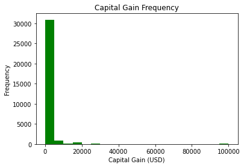

```python
# Visualize using histogram
# Create a histogram
plt.hist(capgain, bins=20, color='green')
plt.xlabel('Capital Gain (USD)')
plt.ylabel('Frequency')
plt.title('Capital Gain Frequency')
plt.show()
```

### Capital-loss column (continuous)

```python
caploss = df['capital-loss']
caploss.describe()
```

```
count    32561.000000
mean        87.303830
std        402.960219
min          0.000000
25%          0.000000
50%          0.000000
75%          0.000000
max       4356.000000
Name: capital-loss, dtype: float64
```

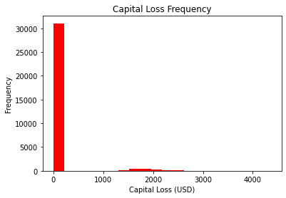

```python
# Visualize using histogram
# Create a histogram
plt.hist(caploss, bins=20, color='red')
plt.xlabel('Capital Loss (USD)')
plt.ylabel('Frequency')
plt.title('Capital Loss Frequency')
plt.show()
```

### Hrs-per-week column (continuous)

```python
hrpw = df['hours-per-week']
hrpw.describe()
```

```
count    32561.000000
mean        40.437456
std         12.347429
min          1.000000
25%         40.000000
50%         40.000000
75%         45.000000
max         99.000000
Name: hours-per-week, dtype: float64
```

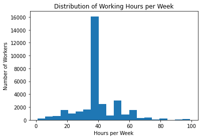

```python
# Visualize using histogram
# Create a histogram
plt.hist(hrpw, bins=20)
plt.xlabel('Hours per Week')
plt.ylabel('Number of Workers')
plt.title('Distribution of Working Hours per Week')
plt.show()
```

### Native-country column (categorical)

```python
nativecountry = df['native-country']
nativecountry.value_counts(normalize=True)
```

```
 United-States                 0.895857
 Mexico                        0.019748
 ?                             0.017905
 Philippines                   0.006081
 Germany                       0.004207
 Canada                        0.003716
 Puerto-Rico                   0.003501
 El-Salvador                   0.003255
 India                         0.003071
 Cuba                          0.002918
 England                       0.002764
 Jamaica                       0.002488
 South                         0.002457
 China                         0.002303
 Italy                         0.002242
 Dominican-Republic            0.002150
 Vietnam                       0.002058
 Guatemala                     0.001966
 Japan                         0.001904
 Poland                        0.001843
 Columbia                      0.001812
 Taiwan                        0.001566
 Haiti                         0.001351
 Iran                          0.001321
 Portugal                      0.001136
 Nicaragua                     0.001044
 Peru                          0.000952
 France                        0.000891
 Greece                        0.000891
 Ecuador                       0.000860
 Ireland                       0.000737
 Hong                          0.000614
 Cambodia                      0.000584
 Trinadad&Tobago               0.000584
 Laos                          0.000553
 Thailand                      0.000553
 Yugoslavia                    0.000491
 Outlying-US(Guam-USVI-etc)    0.000430
 Honduras                      0.000399
 Hungary                       0.000399
 Scotland                      0.000369
 Holand-Netherlands            0.000031
Name: native-country, dtype: float64
```

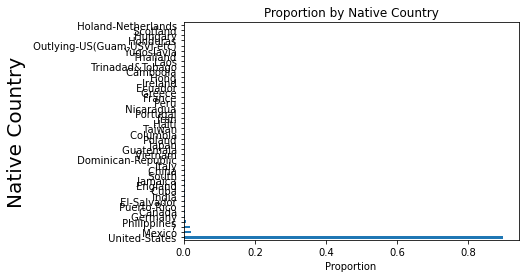

```python
# Analyze the native country category by using plots
nativecountry.value_counts(normalize=True).plot.barh()
plt.xlabel('Proportion')
plt.ylabel('Native Country', fontsize=20)
plt.title('Proportion by Native Country')
plt.show()
```

### **1) Is the data mining task a classification or regression task? In a text block explain the difference between the two.**

The data mining task is a classification task because we are trying to predict the category of an input sample based on its features. Our dataset contains a mix of categorical and continuous variables, such as education, age, occupation, etc. and we are predicting them against our target variable, whether the individual earns more or less than $50,000 a year.

The difference between a regression task and a classification task is that a regression task is used to predict a continuous value for an input and primarily focuses more on numbers. For example, if we are given a dataset of the stock market with features such as price, rates, and other continuous variables, we are trying to predict a number outcome. In summary, the main difference is the type of output that is predicted. Classification tasks output a category, while regression tasks output a continuous value.

### **3) What a majority classifier's accuracy would be on this target variable. ie what accuracy do we need to beat to do better than a majority classifier?**

We just need to have a higher accuracy than whatever to majority classifier is. E.g., if a sample majority class had an accuracy of 50%, we just need a model that is higher than 50%.

### **4) What classification performance metrics will you be using based on what you have learned about the target variable. Rank the metrics you will be using from most important to least important and explain your reasoning for the ranking.**

I used:

1. F1 score - This metric is used to balance the tradeoff between precision and recall. It is a great all-around metric for measuring the overall performance of the models. This is the most important metric for me since its for the overall performance.
2. Precision - This measures the proportions of positive predictions in the models. It ensures that the models are able to accurately identify the minority class.
3. Accuracy - This measures the performance of different models by measuring how well a model is able to learn.
4. Recall - This is used to measure the proportion of positive samples that are correctly predicted. It measures the ability to identify all positive samples.

# Task 4 - Target Variable Exploration

Replicating some of the similar exploration techniques utilized in Task 3 for categorical variables explore your target variable. In this section make sure to document

### Write your interpretation of any predictors that appear to have an obvious relationship with the target.

I believe the columns 'hours-pr-week' and 'education-num' have an obvious relationship with the target because the categories of education num may have a correlation, as individuals with a higher level of education are more likely to earn greater than 50,000. Hours per week is similar, as individuals who work more hours may earn higher income.

```python
y_target = df['y'] # Here I am assigning the y column to its own variable for easier tracking
```

```python
# Lets explore this variable
y_target.value_counts(normalize=True)
```

```
 <=50K    0.75919
 >50K     0.24081
Name: y, dtype: float64
```

There are only two categories within the target variable, either less than or equal to 50,000 or greater than 50,000.

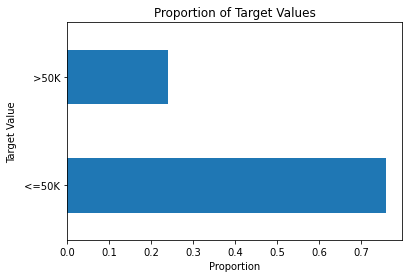

```python
# Let's visualize this
y_target.value_counts(normalize=True).plot.barh()
plt.xlabel('Proportion')
plt.ylabel('Target Value')
plt.title('Proportion of Target Values')
plt.show()
```